# LaLigaDataAnalysis

IMPORT LIBRARIES REQUIRED TO RUN THE CODE:

- Prepare the correct directory to import all properly
- Import required libraries

```python
import os
current_directory = os.getcwd()
parent_directory = os.path.dirname(current_directory)
os.chdir(parent_directory)

import numpy as np
import pandas as pd
import matplotlib.pyplot as plt
import quiniela.io as io

df = io.load_historical_data('all')
df
```

|  | season | division | matchday | date | time | home_team | away_team | score |
| --- | --- | --- | --- | --- | --- | --- | --- | --- |
| 0 | 1928-1929 | 1 | 1 | 2/10/29 | None | Arenas Club | Athletic Madrid | 2:3 |
| 1 | 1928-1929 | 1 | 1 | 2/10/29 | None | Espanyol | Real Unión | 3:2 |
| 2 | 1928-1929 | 1 | 1 | 2/10/29 | None | Real Madrid | Catalunya | 5:0 |
| 3 | 1928-1929 | 1 | 1 | 2/10/29 | None | Donostia | Athletic | 1:1 |
| 4 | 1928-1929 | 1 | 1 | 2/12/29 | None | Racing | Barcelona | 0:2 |
| ... | ... | ... | ... | ... | ... | ... | ... | ... |
| 48775 | 2021-2022 | 2 | 42 | 5/29/22 | None | Real Oviedo | UD Ibiza | None |
| 48776 | 2021-2022 | 2 | 42 | 5/29/22 | None | Real Sociedad B | Real Zaragoza | None |
| 48777 | 2021-2022 | 2 | 42 | 5/29/22 | None | Sporting Gijón | UD Las Palmas | None |
| 48778 | 2021-2022 | 2 | 42 | 5/29/22 | None | CD Tenerife | FC Cartagena | None |
| 48779 | 2021-2022 | 2 | 42 | 5/29/22 | None | Real Valladolid | SD Huesca | None |

48780 rows × 8 columns

### Exercise 1

*Is it true that the home team is more likely to win? Make a pie chart showing the result distribution (whether home team wins, visitor team wins, or there’s a tie) of all matches in the data. Write in the plot the percentage of each category.*

First of all, drop from the dataset the matches that are still to be played.

```python
NotPlayed = df.index[df['score'].isna()]

df = df.drop(index = NotPlayed)
df.head()
```

|  | season | division | matchday | date | time | home_team | away_team | score |
| --- | --- | --- | --- | --- | --- | --- | --- | --- |
| 0 | 1928-1929 | 1 | 1 | 2/10/29 | None | Arenas Club | Athletic Madrid | 2:3 |
| 1 | 1928-1929 | 1 | 1 | 2/10/29 | None | Espanyol | Real Unión | 3:2 |
| 2 | 1928-1929 | 1 | 1 | 2/10/29 | None | Real Madrid | Catalunya | 5:0 |
| 3 | 1928-1929 | 1 | 1 | 2/10/29 | None | Donostia | Athletic | 1:1 |
| 4 | 1928-1929 | 1 | 1 | 2/12/29 | None | Racing | Barcelona | 0:2 |

Then, split the 'score' column in 'home_score' and 'away_score'.

```python
df[['home_score', 'away_score']] = df['score'].str.split(':', expand=True)

df.head()
```

|  | season | division | matchday | date | time | home_team | away_team | score | home_score | away_score |
| --- | --- | --- | --- | --- | --- | --- | --- | --- | --- | --- |
| 0 | 1928-1929 | 1 | 1 | 2/10/29 | None | Arenas Club | Athletic Madrid | 2:3 | 2 | 3 |
| 1 | 1928-1929 | 1 | 1 | 2/10/29 | None | Espanyol | Real Unión | 3:2 | 3 | 2 |
| 2 | 1928-1929 | 1 | 1 | 2/10/29 | None | Real Madrid | Catalunya | 5:0 | 5 | 0 |
| 3 | 1928-1929 | 1 | 1 | 2/10/29 | None | Donostia | Athletic | 1:1 | 1 | 1 |
| 4 | 1928-1929 | 1 | 1 | 2/12/29 | None | Racing | Barcelona | 0:2 | 0 | 2 |

Since they should represent numerical values, we convert these brand-new columns to the integer type.

```python
df[['home_score', 'away_score']] = df[['home_score', 'away_score']].apply(pd.to_numeric)

print(df.dtypes)
```

```
season        object
division       int64
matchday       int64
date          object
time          object
home_team     object
away_team     object
score         object
home_score     int64
away_score     int64
dtype: object
```

Now, create a new categorical column displaying which team won (or whether it was a draw).

```python
conds = [df['home_score'] > df['away_score'],
        df['home_score'] == df['away_score'],
        df['home_score'] < df['away_score']]

choices = ['home', 'draw', 'away']

df['winning_team'] = np.select(condlist=conds, choicelist=choices, default=np.NaN)
df.head()
```

|  | season | division | matchday | date | time | home_team | away_team | score | home_score | away_score | winning_team |
| --- | --- | --- | --- | --- | --- | --- | --- | --- | --- | --- | --- |
| 0 | 1928-1929 | 1 | 1 | 2/10/29 | None | Arenas Club | Athletic Madrid | 2:3 | 2 | 3 | away |
| 1 | 1928-1929 | 1 | 1 | 2/10/29 | None | Espanyol | Real Unión | 3:2 | 3 | 2 | home |
| 2 | 1928-1929 | 1 | 1 | 2/10/29 | None | Real Madrid | Catalunya | 5:0 | 5 | 0 | home |
| 3 | 1928-1929 | 1 | 1 | 2/10/29 | None | Donostia | Athletic | 1:1 | 1 | 1 | draw |
| 4 | 1928-1929 | 1 | 1 | 2/12/29 | None | Racing | Barcelona | 0:2 | 0 | 2 | away |

Finally, we can plot the pie chart!  
It turns out that the home team is indeed more likely to win.

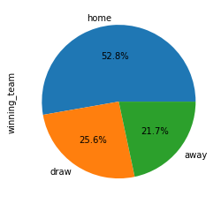

```python
pie = df['winning_team'].value_counts().plot.pie(
    autopct='%1.1f%%')
```

### Exercise 2

*What are the top ten scoring teams of all time? What are the ten teams that concede the most? Make two bar plot charts showing each of them. Consider only matches played in 1st division. What have been the biggest wins? Of course, when we say biggest we mean those with the highest goal difference. Show the top ten of them in a table.*

First of all, we drop form the dataset the matches that were not played in the 1st division.  
In order to double-check the outcome, we count the number of different occurences in the 'division' column.

```python
SecondDivision = df.index[df['division']==2]

df1 = df.drop(index = SecondDivision)
df1['division'].value_counts()
```

```
1    25848
Name: division, dtype: int64
```

Let's find the top ten scoring teams:  
We create a DataFrame for the goals scored by any team and sort it in descending order; then we plot the top 10 values.  
Not surprisingly, Barcelona and Real Madrid are by far the best scorers.

```python
df_home = df1.groupby(by='home_team')
df_away = df1.groupby(by='away_team')

scored_goals = (df_home['home_score'].sum() + df_away['away_score'].sum()).reset_index()
scored_goals.rename(columns={0:'goals_scored'}, inplace=True)
scored_goals = scored_goals.sort_values(by='goals_scored', ascending=False)

scored_goals.head(10)
```

|  | home_team | goals_scored |
| --- | --- | --- |
| 10 | Barcelona | 6267 |
| 48 | Real Madrid | 6249 |
| 5 | Athletic | 4802 |
| 65 | Valencia | 4615 |
| 8 | Atlético Madrid | 4184 |
| 59 | Sevilla FC | 3903 |
| 32 | Espanyol | 3720 |
| 51 | Real Sociedad | 3200 |
| 54 | Real Zaragoza | 2683 |
| 25 | Celta de Vigo | 2483 |

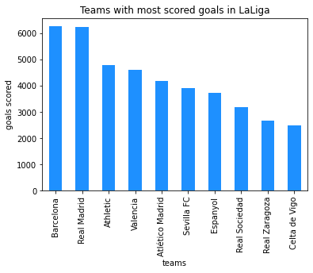

```python
hist = scored_goals[:10].plot(kind='bar', color='dodgerblue')

hist.set_title('Teams with most scored goals in LaLiga');
hist.set_xlabel('teams')
hist.set_ylabel('goals scored')
hist.set_xticklabels(scored_goals['home_team'][:10]);
hist.get_legend().remove()
```

An analogous reasonment gives us an insight on the most conceding teams of the LaLiga history.

Espanyol in on top of the standings, but Barcelona and Real Madrid sit pretty high as well. Of course, this is due to the fact that these are amongst the most present teams in the history of LaLiga. An analysis of the $\frac{goals\_conceded}{matches\_played}$ ratio would give more meaningful information.

```python
conceded_goals = (df_home['away_score'].sum() + df_away['home_score'].sum()).reset_index()
conceded_goals.rename(columns={0:'goals conceded'}, inplace=True)
conceded_goals = conceded_goals.sort_values(by='goals conceded', ascending=False)

conceded_goals.head(10)
```

|  | home_team | goals conceded |
| --- | --- | --- |
| 32 | Espanyol | 4034 |
| 5 | Athletic | 3875 |
| 65 | Valencia | 3649 |
| 59 | Sevilla FC | 3546 |
| 48 | Real Madrid | 3287 |
| 10 | Barcelona | 3259 |
| 51 | Real Sociedad | 3126 |
| 8 | Atlético Madrid | 2894 |
| 25 | Celta de Vigo | 2856 |
| 54 | Real Zaragoza | 2847 |

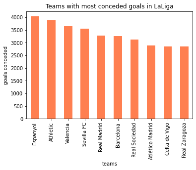

```python
hist = conceded_goals[:10].plot(kind='bar', color='coral')

hist.set_title('Teams with most conceded goals in LaLiga');
hist.set_xlabel('teams')
hist.set_ylabel('goals conceded')
hist.set_xticklabels(conceded_goals['home_team'][:10]);
hist.get_legend().remove()
```

Now we analyze the biggest wins of LaLiga history (only considering 1st division):

```python
df['goal_diff'] = abs(df['home_score'] - df['away_score'])

df.loc[df['division']==1].sort_values(by='goal_diff', ascending=False).head(10)
```

|  | season | division | matchday | date | time | home_team | away_team | score | home_score | away_score | winning_team | goal_diff |
| --- | --- | --- | --- | --- | --- | --- | --- | --- | --- | --- | --- | --- |
| 225 | 1930-1931 | 1 | 10 | 2/8/31 | None | Athletic | Barcelona | 12:1 | 12 | 1 | home | 11 |
| 936 | 1940-1941 | 1 | 1 | 9/29/40 | None | Sevilla FC | Barcelona | 11:1 | 11 | 1 | home | 10 |
| 2787 | 1950-1951 | 1 | 11 | 11/19/50 | None | Athletic | Lérida | 10:0 | 10 | 0 | home | 10 |
| 1168 | 1941-1942 | 1 | 15 | 1/11/42 | None | Athletic | Celta de Vigo | 10:0 | 10 | 0 | home | 10 |
| 1071 | 1941-1942 | 1 | 1 | 9/28/41 | None | Sevilla FC | Real Oviedo | 10:0 | 10 | 0 | home | 10 |
| 3629 | 1953-1954 | 1 | 26 | 3/28/54 | None | Barcelona | Real Oviedo | 9:0 | 9 | 0 | home | 9 |
| 10024 | 1978-1979 | 1 | 16 | 1/14/79 | None | Barcelona | Rayo Vallecano | 9:0 | 9 | 0 | home | 9 |
| 408 | 1932-1933 | 1 | 10 | 1/29/33 | None | Racing | Alavés | 9:0 | 9 | 0 | home | 9 |
| 5027 | 1959-1960 | 1 | 21 | 2/7/60 | None | Real Madrid | Elche CF | 11:2 | 11 | 2 | home | 9 |
| 3911 | 1955-1956 | 1 | 1 | 9/11/55 | None | Atlético Madrid | Hércules CF | 9:0 | 9 | 0 | home | 9 |

### Exercise 3

*There has been a lot of discussion about how LaLiga’s television rights have changed game schedules in the last years. Make a bar plot chart showing the number of matches played each weekday, and make also a histogram of match time. Compare this two graphics between seasons 2000-2001 and 2020-2021.*

We reformat the 'date' column and extract a 'weekday' column from it.

```python
import datetime as dt

def parse_date(date):
    month, day, year = map(int, date.split('/'))
    return dt.date(1900 + year if year > 25 else 2000 + year, month, day)

df['date_'] = df['date'].apply(parse_date)
df['weekday'] = df['date_'].apply(lambda x: x.strftime('%A'))

df[['season', 'date', 'date_', 'weekday']].tail()
```

|  | season | date | date_ | weekday |
| --- | --- | --- | --- | --- |
| 48345 | 2021-2022 | 8/28/21 | 2021-08-28 | Saturday |
| 48346 | 2021-2022 | 8/29/21 | 2021-08-29 | Sunday |
| 48347 | 2021-2022 | 8/29/21 | 2021-08-29 | Sunday |
| 48348 | 2021-2022 | 8/29/21 | 2021-08-29 | Sunday |
| 48349 | 2021-2022 | 8/29/21 | 2021-08-29 | Sunday |

We also refactor the 'time' column in the 24h format.

```python
df['time_24h'] = pd.to_datetime(df['time'], format='%I:%M %p')

df['time_24h'] = df['time_24h'].dt.strftime('%H.%M')

df[['time', 'time_24h']].tail()
```

|  | time | time_24h |
| --- | --- | --- |
| 48345 | 10:00 PM | 22.00 |
| 48346 | 5:00 PM | 17.00 |
| 48347 | 7:30 PM | 19.30 |
| 48348 | 7:30 PM | 19.30 |
| 48349 | 10:00 PM | 22.00 |

Now, we plot the most popular days for football matches: of course, Sundays are by far the most common choice.

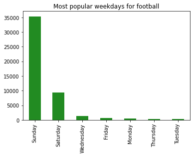

```python
plot = df['weekday'].value_counts().plot(kind='bar', color='forestgreen');
plot.set_title('Most popular weekdays for football');
```

Now, an histogram for the match times. Dinner hours are a natural choice, but most matches start around tea time.

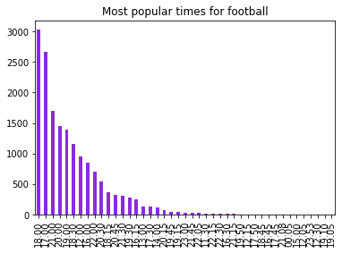

```python
hist = df['time_24h'].value_counts().plot(kind='bar', color='blueviolet');
hist.set_title('Most popular times for football');
```

Now, a comparison between seasons 2000-2001 and 2020-21.  
Caveat: since we have no data on match times of LaLiga2 during the 2000-2001 season, we only consider th first division.

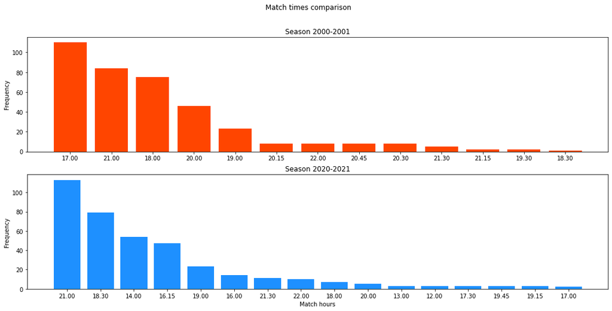

```python
hour2000 = df.loc[(df['season']=='2000-2001') & (df['division']==1)]['time_24h'].value_counts()
hour2020 = df.loc[(df['season']=='2020-2021') & (df['division']==1)]['time_24h'].value_counts()

fig, (ax1, ax2) = plt.subplots(2, 1, sharex=False)
fig.suptitle('Match times comparison')
fig.set_size_inches(18,8)

ax1.bar(hour2000.index, hour2000.values, color='orangered')
ax1.set_ylabel('Frequency')
ax1.set_title('Season 2000-2001')


ax2.bar(hour2020.index, hour2020.values, color='dodgerblue')
ax2.set_xlabel('Match hours')
ax2.set_ylabel('Frequency')
ax2.set_title('Season 2020-2021')


plt.show()
```

In 2000-2001, the majority of the matches were played during the late afternoon or in the evening;  
In 2020-2021, it was not rare to see matches played after lunchtime or in the middle of the afternoon. Moreover, the favorite match time switched from 17:00 to 21:00.

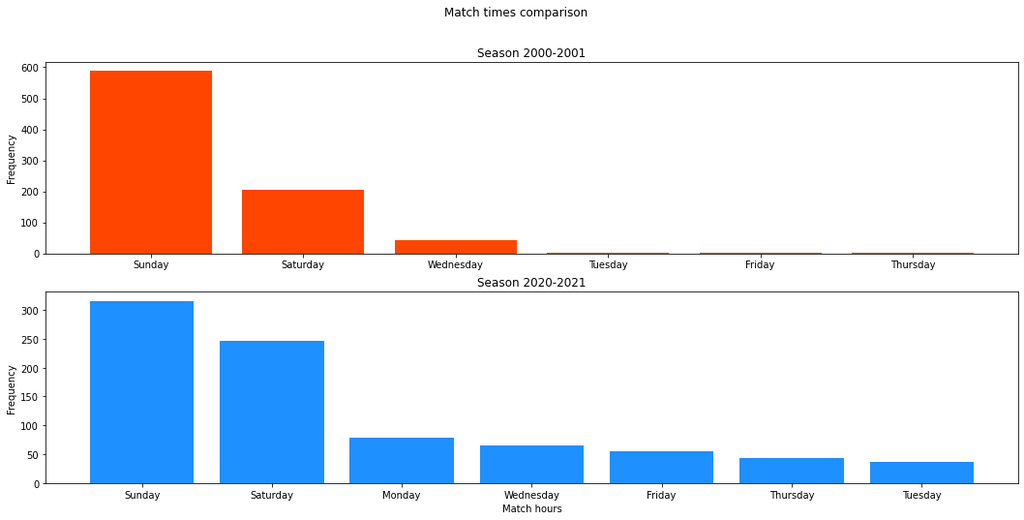

```python
week2000 = df.loc[df['season']=='2000-2001']['weekday'].value_counts()
week2020 = df.loc[df['season']=='2020-2021']['weekday'].value_counts()


fig, (ax1, ax2) = plt.subplots(2, 1, sharex=False)
fig.suptitle('Match times comparison')
fig.set_size_inches(18,8)

ax1.bar(week2000.index, week2000.values, color='orangered')
ax1.set_ylabel('Frequency')
ax1.set_title('Season 2000-2001')


ax2.bar(week2020.index, week2020.values, color='dodgerblue')
ax2.set_xlabel('Match hours')
ax2.set_ylabel('Frequency')
ax2.set_title('Season 2020-2021')


plt.show()
```

But the real difference between these seasons can be seen in the weekdays frequency:  
In 2000-2001, the vast majority of LaLiga matches were hosted in the weekends; in 2020-2021, though, about a third of the matches were distributed in the working days. This is probably due to broadcasting reasons and in order to keep the fans entertained during the whole week.

### Exercise 4

*Build a cross results table for season 2020-2021 (1st division). Figure 1 is an example taken from Wikipedia. Try to make it the most similar to this one, painting the background of each cell according to result (green in case local team wins and red in case visitor team wins). Also, could you model the intensity of this background color with the goal difference from the match? Figure 1: Example of cross results table. Write a function that, given the season and division, plots the cross results table. Function prototype should be like plot_cross_results_table(season, division) and return the plot object.*

First of all, let's filter the dataset using the season we're interested in.

```python
stagione = df.loc[(df['season']=='2020-2021') & (df['division']==1)]
stagione.head()
```

|  | season | division | matchday | date | time | home_team | away_team | score | home_score | away_score | winning_team | goal_diff | date_ | weekday | time_24h |
| --- | --- | --- | --- | --- | --- | --- | --- | --- | --- | --- | --- | --- | --- | --- | --- |
| 25438 | 2020-2021 | 1 | 1 | 9/12/20 | 4:00 PM | SD Eibar | Celta de Vigo | 0:0 | 0 | 0 | draw | 0 | 2020-09-12 | Saturday | 16.00 |
| 25439 | 2020-2021 | 1 | 1 | 9/12/20 | 6:30 PM | Granada CF | Athletic | 2:0 | 2 | 0 | home | 2 | 2020-09-12 | Saturday | 18.30 |
| 25440 | 2020-2021 | 1 | 1 | 9/12/20 | 9:00 PM | Cádiz CF | CA Osasuna | 0:2 | 0 | 2 | away | 2 | 2020-09-12 | Saturday | 21.00 |
| 25441 | 2020-2021 | 1 | 1 | 9/13/20 | 2:00 PM | Alavés | Real Betis | 0:1 | 0 | 1 | away | 1 | 2020-09-13 | Sunday | 14.00 |
| 25442 | 2020-2021 | 1 | 1 | 9/13/20 | 4:00 PM | Real Valladolid | Real Sociedad | 1:1 | 1 | 1 | draw | 0 | 2020-09-13 | Sunday | 16.00 |

Then, let's create a cross results table.

```python
tab = pd.pivot_table(stagione, values='score', index='home_team', columns='away_team', aggfunc=lambda x: ' '.join(x), fill_value='')
tab
```

| away_team home_team | Alavés | Athletic | Atlético Madrid | Barcelona | CA Osasuna | Celta de Vigo | Cádiz CF | Elche CF | Getafe | Granada CF | Levante | Real Betis | Real Madrid | Real Sociedad | Real Valladolid | SD Eibar | SD Huesca | Sevilla FC | Valencia | Villarreal |
| --- | --- | --- | --- | --- | --- | --- | --- | --- | --- | --- | --- | --- | --- | --- | --- | --- | --- | --- | --- | --- |
| Alavés |  | 1:0 | 1:2 | 1:1 | 0:1 | 1:3 | 1:1 | 0:2 | 0:0 | 4:2 | 2:2 | 0:1 | 1:4 | 0:0 | 1:0 | 2:1 | 1:0 | 1:2 | 2:2 | 2:1 |
| Athletic | 0:0 |  | 2:1 | 2:3 | 2:2 | 0:2 | 0:1 | 1:0 | 5:1 | 2:1 | 2:0 | 4:0 | 0:1 | 0:1 | 2:2 | 1:1 | 2:0 | 2:1 | 1:1 | 1:1 |
| Atlético Madrid | 1:0 | 2:1 |  | 1:0 | 2:1 | 2:2 | 4:0 | 3:1 | 1:0 | 6:1 | 0:2 | 2:0 | 1:1 | 2:1 | 2:0 | 5:0 | 2:0 | 2:0 | 3:1 | 0:0 |
| Barcelona | 5:1 | 2:1 | 0:0 |  | 4:0 | 1:2 | 1:1 | 3:0 | 5:2 | 1:2 | 1:0 | 5:2 | 1:3 | 2:1 | 1:0 | 1:1 | 4:1 | 1:1 | 2:2 | 4:0 |
| CA Osasuna | 1:1 | 1:0 | 1:3 | 0:2 |  | 2:0 | 3:2 | 2:0 | 0:0 | 3:1 | 1:3 | 0:2 | 0:0 | 0:1 | 0:0 | 2:1 | 1:1 | 0:2 | 3:1 | 1:3 |
| Celta de Vigo | 2:0 | 0:0 | 0:2 | 0:3 | 2:1 |  | 4:0 | 3:1 | 1:0 | 3:1 | 2:0 | 2:3 | 1:3 | 1:4 | 1:1 | 1:1 | 2:1 | 3:4 | 2:1 | 0:4 |
| Cádiz CF | 3:1 | 0:4 | 2:4 | 2:1 | 0:2 | 0:0 |  | 1:3 | 0:2 | 1:1 | 2:2 | 0:1 | 0:3 | 0:1 | 0:0 | 1:0 | 2:1 | 1:3 | 2:1 | 0:0 |
| Elche CF | 0:2 | 2:0 | 0:1 | 0:2 | 2:2 | 1:1 | 1:1 |  | 1:3 | 0:1 | 1:0 | 1:1 | 1:1 | 0:3 | 1:1 | 1:0 | 0:0 | 2:1 | 2:1 | 2:2 |
| Getafe | 0:0 | 1:1 | 0:0 | 1:0 | 1:0 | 1:1 | 0:1 | 1:1 |  | 0:1 | 2:1 | 3:0 | 0:0 | 0:1 | 0:1 | 0:1 | 1:0 | 0:1 | 3:0 | 1:3 |
| Granada CF | 2:1 | 2:0 | 1:2 | 0:4 | 2:0 | 0:0 | 0:1 | 2:1 | 0:0 |  | 1:1 | 2:0 | 1:4 | 1:0 | 1:3 | 4:1 | 3:3 | 1:0 | 2:1 | 0:3 |
| Levante | 1:1 | 1:1 | 1:1 | 3:3 | 0:1 | 1:1 | 2:2 | 1:1 | 3:0 | 2:2 |  | 4:3 | 0:2 | 2:1 | 2:2 | 2:1 | 0:2 | 0:1 | 1:0 | 1:5 |
| Real Betis | 3:2 | 0:0 | 1:1 | 2:3 | 1:0 | 2:1 | 1:0 | 3:1 | 1:0 | 2:1 | 2:0 |  | 2:3 | 0:3 | 2:0 | 0:2 | 1:0 | 1:1 | 2:2 | 1:1 |
| Real Madrid | 1:2 | 3:1 | 2:0 | 2:1 | 2:0 | 2:0 | 0:1 | 2:1 | 2:0 | 2:0 | 1:2 | 0:0 |  | 1:1 | 1:0 | 2:0 | 4:1 | 2:2 | 2:0 | 2:1 |
| Real Sociedad | 4:0 | 1:1 | 0:2 | 1:6 | 1:1 | 2:1 | 4:1 | 2:0 | 3:0 | 2:0 | 1:0 | 2:2 | 0:0 |  | 4:1 | 1:1 | 4:1 | 1:2 | 0:1 | 1:1 |
| Real Valladolid | 0:2 | 2:1 | 1:2 | 0:3 | 3:2 | 1:1 | 1:1 | 2:2 | 2:1 | 1:2 | 1:1 | 1:1 | 0:1 | 1:1 |  | 1:2 | 1:3 | 1:1 | 0:1 | 0:2 |
| SD Eibar | 3:0 | 1:2 | 1:2 | 0:1 | 0:0 | 0:0 | 0:2 | 0:1 | 0:0 | 2:0 | 0:1 | 1:1 | 1:3 | 0:1 | 1:1 |  | 1:1 | 0:2 | 0:0 | 1:3 |
| SD Huesca | 1:0 | 1:0 | 0:0 | 0:1 | 0:0 | 3:4 | 0:2 | 3:1 | 0:2 | 3:2 | 1:1 | 0:2 | 1:2 | 1:0 | 2:2 | 1:1 |  | 0:1 | 0:0 | 0:0 |
| Sevilla FC | 1:0 | 0:1 | 1:0 | 0:2 | 1:0 | 4:2 | 3:0 | 2:0 | 3:0 | 2:1 | 1:0 | 1:0 | 0:1 | 3:2 | 1:1 | 0:1 | 1:0 |  | 1:0 | 2:0 |
| Valencia | 1:1 | 2:2 | 0:1 | 2:3 | 1:1 | 2:0 | 1:1 | 1:0 | 2:2 | 2:1 | 4:2 | 0:2 | 4:1 | 2:2 | 3:0 | 4:1 | 1:1 | 0:1 |  | 2:1 |
| Villarreal | 3:1 | 1:1 | 0:2 | 1:2 | 1:2 | 2:4 | 2:1 | 0:0 | 1:0 | 2:2 | 2:1 | 1:2 | 1:1 | 1:1 | 2:0 | 2:1 | 1:1 | 4:0 | 2:1 |  |

Now, we create a conditional coloring function and apply it to the table;  
the bigger the goal difference, the darker the color.

```python
def colore_celle(val):
    try:
        home_goals, away_goals = map(int, val.split(':'))

        if home_goals > away_goals:
            if abs(home_goals-away_goals) == 1:
                return 'background-color: SpringGreen; color: black'
            elif abs(home_goals-away_goals) == 2:
                return 'background-color: MediumSeaGreen; color: white'
            elif abs(home_goals-away_goals) == 3:
                return 'background-color: SeaGreen; color: white'
            else:
                return 'background-color: DarkGreen; color: white'

        elif home_goals < away_goals:
            if abs(home_goals-away_goals) == 1:
                return 'background-color: Coral; color: black'
            elif abs(home_goals-away_goals) == 2:
                return 'background-color: Crimson; color: white'
            elif abs(home_goals-away_goals) == 3:
                return 'background-color: FireBrick; color: white'
            else:
                return 'background-color: Maroon; color: white'

        else:
            return 'background-color: gold; color: black'

    except ValueError:
        return ''


tab_color  = tab.style.applymap(colore_celle)
tab_color
```

| away_team home_team | Alavés | Athletic | Atlético Madrid | Barcelona | CA Osasuna | Celta de Vigo | Cádiz CF | Elche CF | Getafe | Granada CF | Levante | Real Betis | Real Madrid | Real Sociedad | Real Valladolid | SD Eibar | SD Huesca | Sevilla FC | Valencia | Villarreal |
| --- | --- | --- | --- | --- | --- | --- | --- | --- | --- | --- | --- | --- | --- | --- | --- | --- | --- | --- | --- | --- |
| Alavés |  | 1:0 | 1:2 | 1:1 | 0:1 | 1:3 | 1:1 | 0:2 | 0:0 | 4:2 | 2:2 | 0:1 | 1:4 | 0:0 | 1:0 | 2:1 | 1:0 | 1:2 | 2:2 | 2:1 |
| Athletic | 0:0 |  | 2:1 | 2:3 | 2:2 | 0:2 | 0:1 | 1:0 | 5:1 | 2:1 | 2:0 | 4:0 | 0:1 | 0:1 | 2:2 | 1:1 | 2:0 | 2:1 | 1:1 | 1:1 |
| Atlético Madrid | 1:0 | 2:1 |  | 1:0 | 2:1 | 2:2 | 4:0 | 3:1 | 1:0 | 6:1 | 0:2 | 2:0 | 1:1 | 2:1 | 2:0 | 5:0 | 2:0 | 2:0 | 3:1 | 0:0 |
| Barcelona | 5:1 | 2:1 | 0:0 |  | 4:0 | 1:2 | 1:1 | 3:0 | 5:2 | 1:2 | 1:0 | 5:2 | 1:3 | 2:1 | 1:0 | 1:1 | 4:1 | 1:1 | 2:2 | 4:0 |
| CA Osasuna | 1:1 | 1:0 | 1:3 | 0:2 |  | 2:0 | 3:2 | 2:0 | 0:0 | 3:1 | 1:3 | 0:2 | 0:0 | 0:1 | 0:0 | 2:1 | 1:1 | 0:2 | 3:1 | 1:3 |
| Celta de Vigo | 2:0 | 0:0 | 0:2 | 0:3 | 2:1 |  | 4:0 | 3:1 | 1:0 | 3:1 | 2:0 | 2:3 | 1:3 | 1:4 | 1:1 | 1:1 | 2:1 | 3:4 | 2:1 | 0:4 |
| Cádiz CF | 3:1 | 0:4 | 2:4 | 2:1 | 0:2 | 0:0 |  | 1:3 | 0:2 | 1:1 | 2:2 | 0:1 | 0:3 | 0:1 | 0:0 | 1:0 | 2:1 | 1:3 | 2:1 | 0:0 |
| Elche CF | 0:2 | 2:0 | 0:1 | 0:2 | 2:2 | 1:1 | 1:1 |  | 1:3 | 0:1 | 1:0 | 1:1 | 1:1 | 0:3 | 1:1 | 1:0 | 0:0 | 2:1 | 2:1 | 2:2 |
| Getafe | 0:0 | 1:1 | 0:0 | 1:0 | 1:0 | 1:1 | 0:1 | 1:1 |  | 0:1 | 2:1 | 3:0 | 0:0 | 0:1 | 0:1 | 0:1 | 1:0 | 0:1 | 3:0 | 1:3 |
| Granada CF | 2:1 | 2:0 | 1:2 | 0:4 | 2:0 | 0:0 | 0:1 | 2:1 | 0:0 |  | 1:1 | 2:0 | 1:4 | 1:0 | 1:3 | 4:1 | 3:3 | 1:0 | 2:1 | 0:3 |
| Levante | 1:1 | 1:1 | 1:1 | 3:3 | 0:1 | 1:1 | 2:2 | 1:1 | 3:0 | 2:2 |  | 4:3 | 0:2 | 2:1 | 2:2 | 2:1 | 0:2 | 0:1 | 1:0 | 1:5 |
| Real Betis | 3:2 | 0:0 | 1:1 | 2:3 | 1:0 | 2:1 | 1:0 | 3:1 | 1:0 | 2:1 | 2:0 |  | 2:3 | 0:3 | 2:0 | 0:2 | 1:0 | 1:1 | 2:2 | 1:1 |
| Real Madrid | 1:2 | 3:1 | 2:0 | 2:1 | 2:0 | 2:0 | 0:1 | 2:1 | 2:0 | 2:0 | 1:2 | 0:0 |  | 1:1 | 1:0 | 2:0 | 4:1 | 2:2 | 2:0 | 2:1 |
| Real Sociedad | 4:0 | 1:1 | 0:2 | 1:6 | 1:1 | 2:1 | 4:1 | 2:0 | 3:0 | 2:0 | 1:0 | 2:2 | 0:0 |  | 4:1 | 1:1 | 4:1 | 1:2 | 0:1 | 1:1 |
| Real Valladolid | 0:2 | 2:1 | 1:2 | 0:3 | 3:2 | 1:1 | 1:1 | 2:2 | 2:1 | 1:2 | 1:1 | 1:1 | 0:1 | 1:1 |  | 1:2 | 1:3 | 1:1 | 0:1 | 0:2 |
| SD Eibar | 3:0 | 1:2 | 1:2 | 0:1 | 0:0 | 0:0 | 0:2 | 0:1 | 0:0 | 2:0 | 0:1 | 1:1 | 1:3 | 0:1 | 1:1 |  | 1:1 | 0:2 | 0:0 | 1:3 |
| SD Huesca | 1:0 | 1:0 | 0:0 | 0:1 | 0:0 | 3:4 | 0:2 | 3:1 | 0:2 | 3:2 | 1:1 | 0:2 | 1:2 | 1:0 | 2:2 | 1:1 |  | 0:1 | 0:0 | 0:0 |
| Sevilla FC | 1:0 | 0:1 | 1:0 | 0:2 | 1:0 | 4:2 | 3:0 | 2:0 | 3:0 | 2:1 | 1:0 | 1:0 | 0:1 | 3:2 | 1:1 | 0:1 | 1:0 |  | 1:0 | 2:0 |
| Valencia | 1:1 | 2:2 | 0:1 | 2:3 | 1:1 | 2:0 | 1:1 | 1:0 | 2:2 | 2:1 | 4:2 | 0:2 | 4:1 | 2:2 | 3:0 | 4:1 | 1:1 | 0:1 |  | 2:1 |
| Villarreal | 3:1 | 1:1 | 0:2 | 1:2 | 1:2 | 2:4 | 2:1 | 0:0 | 1:0 | 2:2 | 2:1 | 1:2 | 1:1 | 1:1 | 2:0 | 2:1 | 1:1 | 4:0 | 2:1 |  |

*Write a function that, given the season and division, plots the cross results table. Function prototype should be like plot_cross_results_table(season, division) and return the plot object.*

```python
def plot_cross_results_table(season, division):

    stagione = df.loc[(df['season']==season) & (df['division']==division)]

    tab = pd.pivot_table(stagione, values='score', index='home_team', columns='away_team', aggfunc=lambda x: ' '.join(x), fill_value='')
    tab_color  = tab.style.applymap(colore_celle)

    return tab_color


plot_cross_results_table('1963-1964', 2)
```

| away_team home_team | Alavés | Burgos CF | CA Osasuna | CE Constància | CE Europa | CE L’Hospitalet | CF Badalona | Celta de Vigo | Dep. La Coruña | Indauchu | Orense | Racing | Real Gijón | Real Sociedad | UD Salamanca | UP Langreo |
| --- | --- | --- | --- | --- | --- | --- | --- | --- | --- | --- | --- | --- | --- | --- | --- | --- |
| Alavés |  | 2:4 | 1:4 | 0:2 | 0:1 | 1:1 | 0:1 | 4:1 | 2:1 | 2:2 | 2:3 | 2:3 | 3:5 | 1:0 | 0:1 | 1:2 |
| Burgos CF | 1:1 |  | 3:2 | 4:1 | 0:2 | 3:0 | 1:0 | 1:1 | 2:3 | 1:0 | 0:1 | 2:1 | 2:1 | 0:3 | 4:0 | 2:1 |
| CA Osasuna | 2:2 | 0:1 |  | 1:0 | 1:0 | 2:1 | 4:0 | 2:1 | 4:1 | 1:1 | 3:0 | 4:4 | 3:3 | 0:1 | 3:2 | 6:2 |
| CE Constància | 2:2 | 2:2 | 2:0 |  | 1:1 | 0:0 | 2:2 | 3:0 | 1:0 | 2:1 | 0:0 | 1:1 | 1:1 | 3:2 | 3:2 | 1:0 |
| CE Europa | 3:2 | 1:0 | 0:1 | 1:1 |  | 1:0 | 2:1 | 0:0 | 2:0 | 3:0 | 1:1 | 1:0 | 2:0 | 3:1 | 2:0 | 0:0 |
| CE L’Hospitalet | 3:2 | 2:0 | 0:2 | 2:1 | 1:1 |  | 3:1 | 2:1 | 3:3 | 2:2 | 2:0 | 4:1 | 0:1 | 1:3 | 2:1 | 3:0 |
| CF Badalona | 7:1 | 4:2 | 2:0 | 2:0 | 0:0 | 2:1 |  | 1:1 | 2:7 | 3:1 | 1:1 | 0:2 | 1:0 | 3:3 | 0:1 | 2:1 |
| Celta de Vigo | 4:0 | 3:0 | 1:2 | 2:1 | 3:2 | 0:0 | 5:0 |  | 1:0 | 1:0 | 2:0 | 2:0 | 1:4 | 2:0 | 1:1 | 0:2 |
| Dep. La Coruña | 8:2 | 0:0 | 3:0 | 8:0 | 2:0 | 4:0 | 3:0 | 2:1 |  | 0:0 | 5:0 | 0:1 | 4:1 | 2:1 | 2:0 | 2:1 |
| Indauchu | 0:0 | 3:0 | 2:2 | 2:1 | 4:1 | 3:1 | 3:1 | 2:1 | 1:2 |  | 3:1 | 0:0 | 0:2 | 0:3 | 0:0 | 2:1 |
| Orense | 3:0 | 0:2 | 4:1 | 2:0 | 3:0 | 0:1 | 1:0 | 1:1 | 2:0 | 2:0 |  | 2:2 | 1:0 | 0:2 | 2:0 | 1:3 |
| Racing | 1:1 | 0:1 | 3:0 | 1:1 | 2:0 | 4:1 | 3:1 | 2:0 | 0:2 | 0:0 | 2:0 |  | 3:0 | 1:4 | 4:0 | 1:0 |
| Real Gijón | 5:0 | 1:0 | 1:1 | 2:0 | 1:0 | 2:1 | 4:1 | 1:2 | 2:2 | 1:0 | 0:1 | 1:0 |  | 5:2 | 4:1 | 3:1 |
| Real Sociedad | 1:0 | 1:1 | 1:0 | 0:0 | 1:2 | 5:0 | 1:1 | 2:0 | 1:3 | 2:1 | 2:1 | 0:1 | 0:1 |  | 2:1 | 3:0 |
| UD Salamanca | 0:2 | 1:1 | 1:2 | 0:0 | 1:2 | 3:1 | 1:0 | 1:0 | 0:1 | 2:1 | 0:0 | 1:2 | 0:0 | 2:1 |  | 2:2 |
| UP Langreo | 0:0 | 1:0 | 1:0 | 4:1 | 0:2 | 2:1 | 3:0 | 1:1 | 1:4 | 0:0 | 1:1 | 1:0 | 0:1 | 0:0 | 2:0 |  |

### Exercise 5

*As you surely know, there has always been a historical rivalry between Barcelona and Real Madrid. But which of them has won the most games in direct confrontations? Which of them has scored the most goals in these games? Show both things in two pie charts, side by side. Remember to con- sider ties in the first one. Write a function that, given two team names, plots the two graphs described above. Function prototype should be like plot_direct_confrontations_stats(team1, team2) and return the plot object. Use it with some other classical rivals like Betis and Sevilla.*

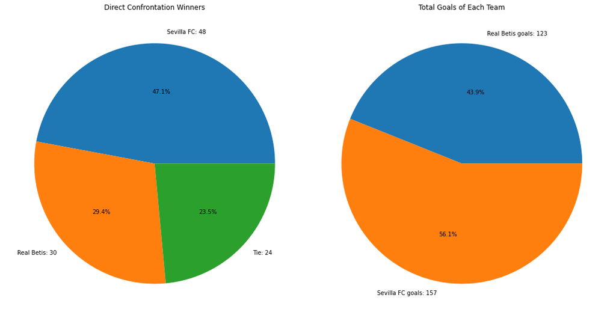

```python
def plot_direct_confrontations_stats(team1, team2):
    data = io.load_historical_data('all')
    data = data[data['score'].notnull()]
    data_teams = data.loc[((data['home_team'] == team1) | (data['home_team'] == team2)) & ((data['away_team'] == team1) | (data['away_team'] == team2))]
    data_teams['winner'] = ''
    goals_team_1 = 0
    goals_team_2 = 0

    for index , row in data_teams.iterrows():
        home_goals, away_goals = map(int, row['score'].split(':'))
        if row['home_team'] == team1:
            goals_team_1 += home_goals
            goals_team_2 += away_goals

        else:
            goals_team_2 += home_goals
            goals_team_1 += away_goals

        if home_goals > away_goals:
            data_teams.at[index, 'winner'] = row['home_team']
        elif away_goals > home_goals:
            data_teams.at[index, 'winner'] = row['away_team']
        else:
            data_teams.at[index, 'winner'] = 'Tie'

    fig, ax = plt.subplots(1, 2, figsize=(15,9))

    winner_counts = data_teams['winner'].value_counts()
    ax[0].pie(winner_counts, labels=[f"{team}: {count}" for team, count in winner_counts.items()], autopct='%1.1f%%')
    ax[0].set_title('Direct Confrontation Winners')

    ax[1].pie([goals_team_1, goals_team_2], labels=[f'{team1} goals: {goals_team_1}', f'{team2} goals: {goals_team_2}'], autopct='%1.1f%%')
    ax[1].set_title('Total Goals of Each Team')

    plt.tight_layout()

    return data_teams, fig, ax

# You can choose whichever teams you want that have played against each one any time
team1 = 'Real Betis'
team2 = 'Sevilla FC'
data_ex_5, fig, ax = plot_direct_confrontations_stats(team1, team2)

plt.show()
```

We can see that Sevilla dominates quite more than Betis. Not only does it has more goals, but also it has won almost half of the matches, while Betis has only won a 30%.

Regarding the Barcelona vs Madrid:

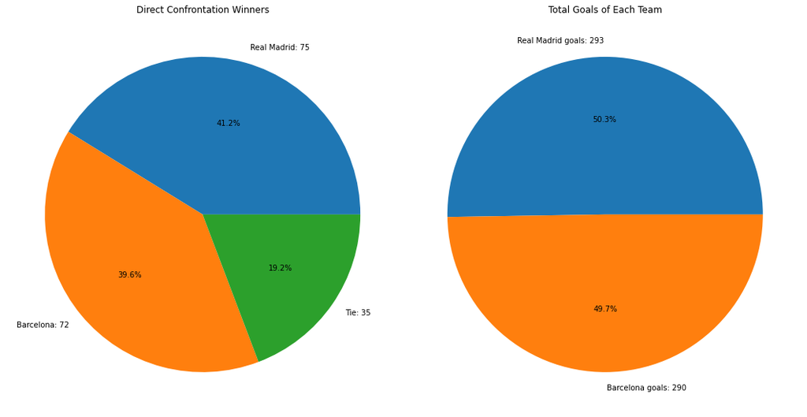

```python
team1 = 'Real Madrid'
team2 = 'Barcelona'
data_ex_5, fig, ax = plot_direct_confrontations_stats(team1, team2)

plt.show()
```

In this case, this matchup is more even. Really close actually. They have scored almost the same goals and also have more or less a 40% of the wins, with just a few more of the Real Madrid.

### Exercise 6

*Between 1979 and 1980, Real Sociedad managed to chain a total of 38 games without losing. That was, by far, the longest undefeated streak in their history. Which teams have had the longest undefeated streaks? Show the longest undefeated streaks in a horizontal bar plot, indicating in each bar the team name and the dates it held that streak, for instance, Real Sociedad 22/04/1979 - 04/05/1980.*

```python
df = io.load_historical_data('all')
NotPlayed = df.index[df['score'].isna()]

df = df.drop(index = NotPlayed)

def home_goals(num):
    try:
        return int(str(num)[0])
    except (ValueError, IndexError):
        return None
def away_goals(num):
    try:
        return int(str(num)[2])
    except (ValueError, IndexError):
        return None
```

```python
df['home_goals'] = df['score'].apply(home_goals)
df.dropna(subset=['home_goals'], inplace=True)
df['home_goals'] = df['home_goals'].astype(int)
df['away_goals'] = df['score'].apply(away_goals)
df.dropna(subset=['away_goals'], inplace=True)
df['away_goals'] = df['away_goals'].astype(int)
```

First we define Winner column

```python
df['Winner'] = np.where(df['home_goals'] > df['away_goals'], df['home_team'],
    np.where(df['home_goals'] < df['away_goals'], df['away_team'], 'Tie'))
df.head()
```

|  | season | division | matchday | date | time | home_team | away_team | score | home_goals | away_goals | Winner |
| --- | --- | --- | --- | --- | --- | --- | --- | --- | --- | --- | --- |
| 0 | 1928-1929 | 1 | 1 | 2/10/29 | None | Arenas Club | Athletic Madrid | 2:3 | 2 | 3 | Athletic Madrid |
| 1 | 1928-1929 | 1 | 1 | 2/10/29 | None | Espanyol | Real Unión | 3:2 | 3 | 2 | Espanyol |
| 2 | 1928-1929 | 1 | 1 | 2/10/29 | None | Real Madrid | Catalunya | 5:0 | 5 | 0 | Real Madrid |
| 3 | 1928-1929 | 1 | 1 | 2/10/29 | None | Donostia | Athletic | 1:1 | 1 | 1 | Tie |
| 4 | 1928-1929 | 1 | 1 | 2/12/29 | None | Racing | Barcelona | 0:2 | 0 | 2 | Barcelona |

Find longest undefeated streaks for each team and season.

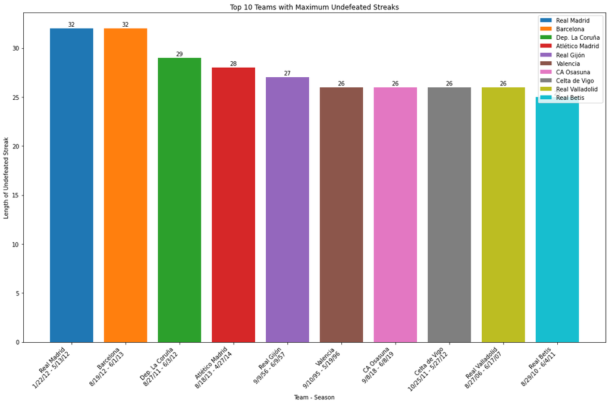

```python
def find_longest_undefeated_streaks(df, team_column='Winner', date_column='date'):
    undefeated_streaks = []
    current_streak = []

    if team_column not in df.columns or date_column not in df.columns:
        print(f"Columns '{team_column}' or '{date_column}' not found in the DataFrame.")
        return

    current_start = ''
    current_end = ''

    for _, row in df.iterrows():
        if row[team_column] == 'Tie':
            # Skip 'Tie' only if it's the first match of the streak
            if current_streak:
                current_streak = []
        elif row[team_column] not in current_streak:
            current_streak = [row[team_column]]
            current_start = row[date_column]
        else:
            current_streak.append(row[team_column])
            current_end = row[date_column]

        if len(current_streak) > len(undefeated_streaks):
            undefeated_streaks = current_streak.copy()

    return undefeated_streaks, current_start, current_end


def find_season_with_max_undefeated_streak(df, team_column='Winner', date_column='date', season_column='season'):
    max_streak_by_team = {}

    if team_column not in df.columns or date_column not in df.columns or season_column not in df.columns:
        print(f"Columns '{team_column}', '{date_column}', or '{season_column}' not found in the DataFrame.")
        return

    for team in df[team_column].unique():
        team_df = df[df[team_column] == team]
        max_streak = 0
        max_start = ''
        max_end = ''
        max_season = None

        for season in team_df[season_column].unique():
            season_df = team_df[team_df[season_column] == season]
            streak, start, end = find_longest_undefeated_streaks(season_df, team_column, date_column)

            if len(streak) > max_streak:
                max_streak = len(streak)
                max_start = start
                max_end = end
                max_season = season

        max_streak_by_team[team] = {'streak': max_streak, 'start': max_start, 'end': max_end, 'season': max_season}

    return max_streak_by_team


def plot_top_teams_with_max_undefeated_streaks(df, team_column='Winner', date_column='date', season_column='season', top_n=10):
    max_streak_by_team = find_season_with_max_undefeated_streak(df, team_column, date_column, season_column)

    # Sort teams based on maximum streak length
    sorted_teams = sorted(max_streak_by_team.keys(), key=lambda x: max_streak_by_team[x]['streak'], reverse=True)[:top_n]

    # Plot the information for the top teams
    fig, ax = plt.subplots(figsize=(15, 10))

    for team in sorted_teams:
        data = max_streak_by_team[team]
        max_streak = data['streak']
        max_start = data['start']
        max_end = data['end']
        max_season = data['season']
        team_df = df[(df[team_column] == team) & (df[season_column] == max_season)]
        dates, start, end = find_longest_undefeated_streaks(team_df, team_column, date_column)

        ax.bar(f"{team}\n{start} - {end}", max_streak, label=team)
        ax.text(f"{team}\n{start} - {end}", max_streak + 0.1, str(max_streak), ha='center', va='bottom')

    ax.set_xlabel('Team - Season')
    ax.set_ylabel('Length of Undefeated Streak')
    ax.set_title(f'Top {top_n} Teams with Maximum Undefeated Streaks')
    ax.legend()

    plt.xticks(rotation=45, ha='right')
    plt.tight_layout()
    plt.show()

# Assuming df contains the necessary columns including 'Winner', 'date', and 'season'
plot_top_teams_with_max_undefeated_streaks(df, top_n=10)
```

### Exercise 7

*Create a table with the final standings of each season (and division), that is, a table that contains all the teams ordered (in descending order) by the number of points they got during that season, and some other aggregate statistics. The table must contain the following columns: season, division, ranking, team, GF (total goals scored), GA (total goals conceded), GD (goals difference), W (total wins), L (total loses), T (total ties), Pts (points). Remem ber that, in football, you earn 3 points per victory, and 1 point per tie (none for loses). In case two teams have same number of points, order by GD (descending), and then by GF (also descending). Order the table so that standings of one season come before standings of previous one, and standings of 1st division come before standings of 2nd division.*

```python
def final_standings_every_season_division():
    data = io.load_historical_data('all')
    data[['local_goals', 'visitor_goals']] = data['score'].str.split(':', expand=True).astype(float)
    data['winner'] = data.apply(determine_winner, axis=1)
    data['goal_difference'] = data['local_goals'] - data['visitor_goals']
    home_team_df = data.copy()
    home_team_df['team'], home_team_df['rival'], home_team_df['condition'] = home_team_df['home_team'], home_team_df['away_team'], 'local'
    away_team_df = data.copy()
    away_team_df['team'], away_team_df['rival'], away_team_df['condition']= away_team_df['away_team'], away_team_df['home_team'], 'visitor'

    matches_data = pd.concat([home_team_df, away_team_df], ignore_index=True).sort_values(by=['season', 'division', 'team', 'matchday'])
    matches_data.reset_index(drop=True, inplace=True)

    matches_data['GF'] = matches_data.apply(lambda row: row['local_goals'] if row['condition'] == 'local' else row['visitor_goals'], axis=1)
    matches_data['GA'] = matches_data.apply(lambda row: row['visitor_goals'] if row['condition'] == 'local' else row['local_goals'], axis=1)
    matches_data['W'] = ((matches_data['winner'] == 'Local') & (matches_data['condition'] == 'local')) | ((matches_data['winner'] == 'Visitor') & (matches_data['condition'] == 'visitor'))
    matches_data['L'] = ((matches_data['winner'] == 'Visitor') & (matches_data['condition'] == 'local')) | ((matches_data['winner'] == 'Local') & (matches_data['condition'] == 'visitor'))
    matches_data['T'] = (matches_data['winner'] == 'Tie')

    final_ranking = matches_data.groupby(['season', 'division', 'team']).agg(
                                                                    GF=('GF', 'sum'),
                                                                    GA=('GA', 'sum'),
                                                                    W=('W', 'sum'),
                                                                    L=('L', 'sum'),
                                                                    T=('T', 'sum')
    ).reset_index()

    final_ranking.drop(final_ranking[final_ranking['season'] == '2021-2022'].index, inplace=True)

    final_ranking['GD'] = final_ranking['GF'] - final_ranking['GA']
    final_ranking['Pts'] = final_ranking['W'] * 3 + final_ranking['T']
    final_ranking = final_ranking.sort_values(by=['season', 'division', 'Pts', 'GD'], ascending=[False, True, False, False])
    final_ranking.reset_index(drop=True, inplace=True)
    final_ranking['rank'] = final_ranking.groupby(['season', 'division'])['Pts'].rank(ascending=False, method='first').astype(int)

    final_ranking = final_ranking[['season', 'division', 'rank', 'team', 'GF', 'GA', 'GD', 'W', 'L', 'T', 'Pts']]

    final_ranking.to_excel('./reports/SeasonStandings.xlsx', index=False)

    return final_ranking


# Aux functions for Ex7
def determine_winner(row):
    if row['local_goals'] > row['visitor_goals']:
        return 'Local'
    elif row['local_goals'] < row['visitor_goals']:
        return 'Visitor'
    else:
        return 'Tie'
```

```python
final_standings_every_season_division()
```

|  | season | division | rank | team | GF | GA | GD | W | L | T | Pts |
| --- | --- | --- | --- | --- | --- | --- | --- | --- | --- | --- | --- |
| 0 | 2020-2021 | 1 | 1 | Atlético Madrid | 67.0 | 25.0 | 42.0 | 26 | 4 | 8 | 86 |
| 1 | 2020-2021 | 1 | 2 | Real Madrid | 67.0 | 28.0 | 39.0 | 25 | 4 | 9 | 84 |
| 2 | 2020-2021 | 1 | 3 | Barcelona | 85.0 | 38.0 | 47.0 | 24 | 7 | 7 | 79 |
| 3 | 2020-2021 | 1 | 4 | Sevilla FC | 53.0 | 33.0 | 20.0 | 24 | 9 | 5 | 77 |
| 4 | 2020-2021 | 1 | 5 | Real Sociedad | 59.0 | 38.0 | 21.0 | 17 | 10 | 11 | 62 |
| ... | ... | ... | ... | ... | ... | ... | ... | ... | ... | ... | ... |
| 2739 | 1928-1929 | 1 | 6 | Athletic Madrid | 43.0 | 41.0 | 2.0 | 8 | 8 | 2 | 26 |
| 2740 | 1928-1929 | 1 | 7 | Espanyol | 32.0 | 38.0 | -6.0 | 7 | 7 | 4 | 25 |
| 2741 | 1928-1929 | 1 | 8 | Catalunya | 45.0 | 49.0 | -4.0 | 6 | 8 | 4 | 22 |
| 2742 | 1928-1929 | 1 | 9 | Real Unión | 40.0 | 42.0 | -2.0 | 5 | 11 | 2 | 17 |
| 2743 | 1928-1929 | 1 | 10 | Racing | 25.0 | 50.0 | -25.0 | 3 | 12 | 3 | 12 |

2744 rows × 11 columns

### Exercise 8

*Villarreal is a team that has grown a lot in recent decades. Specially ever since some billionaire guy bought it (Fernando Roig, from Mercadona). Make a line plot showing the rank of Villarreal at the end of each season, from the oldest ones (left) to the earliest ones (right). Consider rankings in 2nd division to be a continuation of the 1st one, that is, if there’s N teams in 1st division and Villarreal got r position in 2nd division, then it should be placed in N +r. Draw in the same plot a line showing the cut between 1st and 2nd division.*

*Write a function that, given n team names, plots the graph described above of each one of them superposed. Function prototype should be like plot_- ranking_evolution(team1, team2, ..., teamN) and return the plot ob- ject (note that function should not take one array-type argument, but n ar- guments). Use it to compare the evolution of all the teams that currently play in 1st division.*

doubts: Do I need to write an analysis comparing the evolution of all teams of 1st division?

```python
from matplotlib.ticker import FuncFormatter
def calculate_global_rank(row, last_rank_div_1_dict):
    global_rank = row['rank']
    if row['division'] == 2:
        last_rank = last_rank_div_1_dict.get(row['year'], 0)
        global_rank += last_rank

    return global_rank


def years2season(x, year):
    year = int(x)
    return f"{year}-{year+1}"


def plot_ranking_evolution(*teams):
    data = final_standings_every_season_division()
    teams_rankings_evolution = {team: [] for team in teams}
    last_rank_div_1 = data.loc[data['division'] == 1].groupby('season')['rank'].max().tolist()
    data['year'] = data['season'].str.split('-').str[0].astype(int)
    years = data['year'].unique().tolist()[::-1]
    last_rank_div_1_dict = dict(zip(years, last_rank_div_1))
    for team in teams:
        team_data = data.loc[data['team'] == team][['year', 'division', 'rank']]
        team_data['global rank'] = team_data.apply(calculate_global_rank, axis=1, last_rank_div_1_dict=last_rank_div_1_dict)
        teams_rankings_evolution[team] = [team_data['year'].to_list(), team_data['global rank'].to_list()]

    plt.figure(figsize=(30, 10))
    n_teams = len(teams)
    colors = plt.cm.rainbow(np.linspace(0, 1, n_teams))

    for i, team in enumerate(teams):
        plt.plot(teams_rankings_evolution[team][0], teams_rankings_evolution[team][1], marker='o', linestyle='-', color=colors[i], label=team )

    min_year = min(min(year for year in teams_rankings_evolution[team][0]) for team in teams)
    filtered_years = [year for year in years if year >= min_year]
    plt.plot(filtered_years, last_rank_div_1[-(len(filtered_years)):], linestyle='--', color='black', label='Separation between 1st and 2nd division')

    min_ranking = 1
    max_ranking = max(max(ranking for ranking in teams_rankings_evolution[team][1]) for team in teams)

    y_ticks = list(range(min_ranking, max_ranking + 1))
    x_ticks = filtered_years[::2]
    plt.xticks(x_ticks, rotation=45)
    plt.yticks(y_ticks)
    # plt.gca().invert_xaxis()
    plt.gca().invert_yaxis()
    plt.gca().xaxis.set_major_formatter(FuncFormatter(years2season))
    plt.legend()
    plt.xlabel('Season')
    plt.ylabel('Ranking')
    plt.title("Teams' rank evoluiton")
    plt.grid(True)
    plt.show()
```

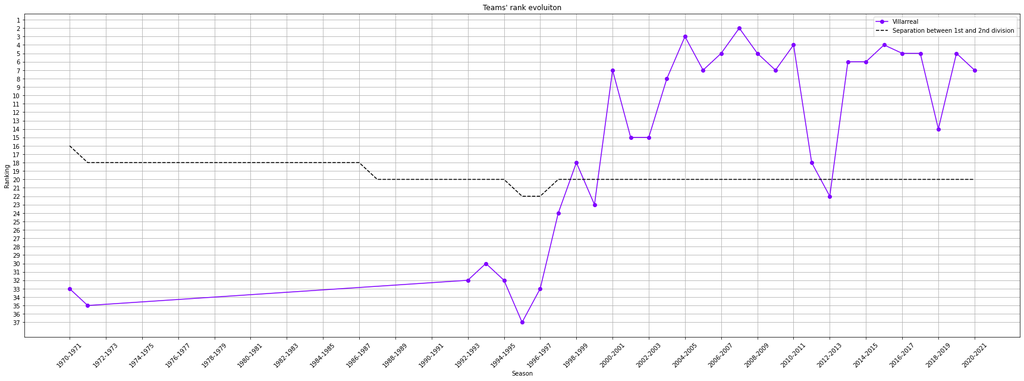

```python
plot_ranking_evolution('Villarreal')
```

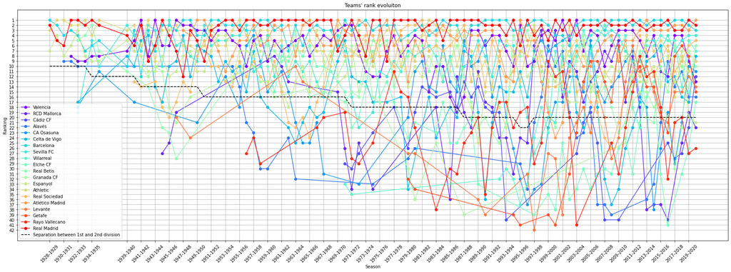

```python
data = io.load_historical_data('all')
data_current_division = data.loc[(data['season'] == '2021-2022') & (data['division'] == 1)]
current_teams_division_1 = data_current_division['home_team'].unique()
plot_ranking_evolution(*current_teams_division_1)
```

### Exercise 9

*In football jargon, those teams that are permanently descending and as- cending between 1st and 2nd division are called elevator teams. What are the most elevator teams in LaLiga? Plot the history of the top 5 of them using the function from exercise 9.*

```python
class Team:
    def __init__(self, team, initial_div):
        self.team = team
        self.actual_div = initial_div
        self.elevator_count = -1 # When it initializes and reads the first season, all update to 0


def change_division(row, team_class):
    if row['division'] != team_class.actual_div:
        team_class.elevator_count += 1
        team_class.actual_div = row['division']


def plot_elevator_teams():
    # It will consider elevator each time the team change division

    data = final_standings_every_season_division()
    team_names = data['team'].unique()
    teams_info = {}
    for team in team_names:
        teams_info[team] = Team(team, 0)
        team_data = data.loc[data['team'] == team]
        team_data.apply(change_division, axis=1, team_class=teams_info[team])

    sorted_teams = sorted(teams_info.values(), key=lambda team: team.elevator_count, reverse=True)
    top_5_teams = [team.team for team in sorted_teams[:5]]
    for team in top_5_teams:
        print(f"team: {team} with counter at {teams_info[team].elevator_count}\n")

    plot_ranking_evolution(*top_5_teams)
```

```
team: Dep. La Coruña with counter at 20

team: Celta de Vigo with counter at 17

team: Racing with counter at 17

team: Real Betis with counter at 14

team: Rayo Vallecano with counter at 14
```

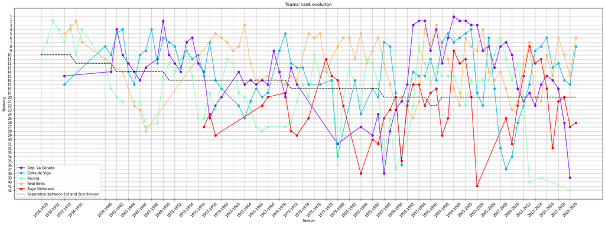

```python
plot_elevator_teams()
```

### Exercise 10

*Create a table that is the same as the one in exercise 7, but not only with the season final standings, but the standings at the end of each matchday. Columns are the same, including matchday that tells about which match- day from the season these standings are from. Would you be able to add a new column last_5 with the result of last 5 matches? This column should contain a list like ["W", "L", "W", "T", "T"]. In this list, the first item is the immediate previous match, the second one is the match before this one, and so on. If there are no 5 previous matches (because matchday < 6, for instance) then just make the list shorter. Save the final table in Excel with the name MatchdayStandings.xlsx in the reports/ folder.*

```python
def final_standings_every_season_division_matchday():
    data = io.load_historical_data('all')
    data[['local_goals', 'visitor_goals']] = data['score'].str.split(':', expand=True).astype(float)
    data['winner'] = data.apply(determine_winner, axis=1)
    data['goal_difference'] = data['local_goals'] - data['visitor_goals']
    home_team_df = data.copy()
    home_team_df['team'], home_team_df['rival'], home_team_df['condition'] = home_team_df['home_team'], home_team_df['away_team'], 'local'
    away_team_df = data.copy()
    away_team_df['team'], away_team_df['rival'], away_team_df['condition']= away_team_df['away_team'], away_team_df['home_team'], 'visitor'

    matches_data = pd.concat([home_team_df, away_team_df], ignore_index=True).sort_values(by=['season', 'division', 'team', 'matchday'])
    matches_data.reset_index(drop=True, inplace=True)
    matches_data['GF_match'] = matches_data.apply(lambda row: row['local_goals'] if row['condition'] == 'local' else row['visitor_goals'], axis=1)
    matches_data['GA_match'] = matches_data.apply(lambda row: row['visitor_goals'] if row['condition'] == 'local' else row['local_goals'], axis=1)
    matches_data['W_match'] = ((matches_data['winner'] == 'Local') & (matches_data['condition'] == 'local')) | ((matches_data['winner'] == 'Visitor') & (matches_data['condition'] == 'visitor'))
    matches_data['L_match'] = ((matches_data['winner'] == 'Visitor') & (matches_data['condition'] == 'local')) | ((matches_data['winner'] == 'Local') & (matches_data['condition'] == 'visitor'))
    matches_data['T_match'] = (matches_data['winner'] == 'Tie')
    matches_data['match_result'] = matches_data.apply(match_result, axis=1)
    matches_data['last_match_result_1'] = matches_data.groupby(['season', 'team'])['match_result'].shift(1)
    matches_data['last_match_result_2'] = matches_data.groupby(['season', 'team'])['match_result'].shift(2)
    matches_data['last_match_result_3'] = matches_data.groupby(['season', 'team'])['match_result'].shift(3)
    matches_data['last_match_result_4'] = matches_data.groupby(['season', 'team'])['match_result'].shift(4)
    matches_data['last_match_result_5'] = matches_data.groupby(['season', 'team'])['match_result'].shift(5)
    matches_data['last_5_results'] = matches_data[['last_match_result_1', 'last_match_result_2', 'last_match_result_3',
                                                'last_match_result_4', 'last_match_result_5']].values.tolist()

    matches_data['GF'] = matches_data.groupby(['season', 'team'])['GF_match'].cumsum()
    matches_data['GA'] = matches_data.groupby(['season', 'team'])['GA_match'].cumsum()
    matches_data['W'] = matches_data.groupby(['season', 'team'])['W_match'].cumsum()
    matches_data['L'] = matches_data.groupby(['season', 'team'])['L_match'].cumsum()
    matches_data['T'] = matches_data.groupby(['season', 'team'])['T_match'].cumsum()

    final_ranking = matches_data.reset_index()
    final_ranking.drop(final_ranking[final_ranking['season'] == '2021-2022'].index, inplace=True)
    final_ranking['GD'] = final_ranking['GF'] - final_ranking['GA']
    final_ranking['Pts'] = final_ranking['W'] * 3 + final_ranking['T']
    final_ranking = final_ranking.sort_values(by=['season', 'division', 'matchday', 'Pts', 'GD'], ascending=[False, True, True, False, False])
    final_ranking.reset_index(drop=True, inplace=True)
    final_ranking['rank'] = final_ranking.groupby(['season', 'division', 'matchday'])['Pts'].rank(ascending=False, method='first').astype(int)

    final_ranking = final_ranking[['season', 'division', 'matchday', 'rank', 'team', 'GF', 'GA', 'GD', 'W', 'L', 'T', 'Pts', 'last_5_results']]
    final_ranking.to_excel('./reports/MatchdayStandings.xlsx', index=False)

    return final_ranking


# Aux function for Ex10
def determine_winner(row):
    if row['local_goals'] > row['visitor_goals']:
        return 'Local'
    elif row['local_goals'] < row['visitor_goals']:
        return 'Visitor'
    else:
        return 'Tie'

def match_result(row):
    if row['W_match'] == True:
        return 'W'
    elif row['L_match'] == True:
        return 'L'
    elif row['T_match'] == True:
        return 'T'
```

```python
final_standings_every_season_division_matchday()
```

|  | season | division | matchday | rank | team | GF | GA | GD | W | L | T | Pts | last_5_results |
| --- | --- | --- | --- | --- | --- | --- | --- | --- | --- | --- | --- | --- | --- |
| 0 | 2020-2021 | 1 | 1 | 1 | Barcelona | 3.0 | 0.0 | 3.0 | 1 | 0 | 0 | 3 | [nan, nan, nan, nan, nan] |
| 1 | 2020-2021 | 1 | 1 | 2 | Atlético Madrid | 2.0 | 0.0 | 2.0 | 1 | 0 | 0 | 3 | [nan, nan, nan, nan, nan] |
| 2 | 2020-2021 | 1 | 1 | 3 | CA Osasuna | 2.0 | 0.0 | 2.0 | 1 | 0 | 0 | 3 | [nan, nan, nan, nan, nan] |
| 3 | 2020-2021 | 1 | 1 | 4 | Granada CF | 2.0 | 0.0 | 2.0 | 1 | 0 | 0 | 3 | [nan, nan, nan, nan, nan] |
| 4 | 2020-2021 | 1 | 1 | 5 | Real Madrid | 2.0 | 0.0 | 2.0 | 1 | 0 | 0 | 3 | [nan, nan, nan, nan, nan] |
| ... | ... | ... | ... | ... | ... | ... | ... | ... | ... | ... | ... | ... | ... |
| 95871 | 1928-1929 | 1 | 18 | 6 | Athletic Madrid | 43.0 | 41.0 | 2.0 | 8 | 8 | 2 | 26 | [T, W, W, L, L] |
| 95872 | 1928-1929 | 1 | 18 | 7 | Espanyol | 32.0 | 38.0 | -6.0 | 7 | 7 | 4 | 25 | [T, L, L, T, T] |
| 95873 | 1928-1929 | 1 | 18 | 8 | Catalunya | 45.0 | 49.0 | -4.0 | 6 | 8 | 4 | 22 | [W, L, T, T, W] |
| 95874 | 1928-1929 | 1 | 18 | 9 | Real Unión | 40.0 | 42.0 | -2.0 | 5 | 11 | 2 | 17 | [L, L, L, W, L] |
| 95875 | 1928-1929 | 1 | 18 | 10 | Racing | 25.0 | 50.0 | -25.0 | 3 | 12 | 3 | 12 | [L, W, L, T, T] |

95876 rows × 13 columns